# Case Study 2

Miguel Bonilla

4/11/2022

*Attrition and Monthly Incomes*

Data analysis on attrition rate and monthly incomes for Case Study 2.Including the an EDA on factors that lead to attrition, as well as the Naive Bayes and Random Forest models used to classify attrition, and the linear regression model fitted to predict salaries.

*Link to the presentation: https://youtu.be/J8LCQuIscLE*

```r
#load libraries
library(MASS)
library(caret)
library(randomForest)
library(e1071)
library(kableExtra)
library(tidyverse)
library(ggthemes)
library(naivebayes)
library(readxl)
```

Load given dataset with information on over 800 employees. Create categorical variables for finding categorical patterns.

```r
csdata <- read.csv('CaseStudy2-data.csv')

csdata1 <- csdata %>% mutate(fAge=cut(Age,
                                     breaks=c(10,20,25,30,40,50,80),
                                     labels=c("18-20", "21-25", "26-30", "31-40","40-50", "50+")),
                             Attrition=as.factor(Attrition),
                             BusinessTravel=as.factor(BusinessTravel),
                             fDailyRate=cut(DailyRate,
                                           DailyRate,
                                           breaks=c(100,200,300,500,750,1000,1250,1500),
                                           labels=c("100-200", "201-300", "301-500", "501-750", "751-1000", "1001-1250", "1251+")),
                             Department=as.factor(Department),
                             fDistanceFromHome=cut(DistanceFromHome,
                                                 breaks=c(0,5,10,15,20,25,30),
                                                 labels=c("<5","6-10","11-15","16-20","21-25","26-30")),
                             Education=as.factor(Education),
                             EducationField=as.factor(EducationField),
                             EnvironmentSatisfaction=as.factor(EnvironmentSatisfaction),
                             Gender=as.factor(Gender),
                             fHourlyRate=cut(HourlyRate,
                                            breaks=c(0,40,50,60,75,90,200),
                                            labels=c("<40","41-50","51-60","61-75","76-90","90+")),
                             JobInvolvement=as.factor(JobInvolvement),
                             JobLevel=as_factor(JobLevel),
                             JobRole=as.factor(JobRole),
                             JobSatisfaction=as.factor(JobSatisfaction),
                             MaritalStatus=as.factor(MaritalStatus),
                             fMonthlyIncome=cut(MonthlyIncome,
                                               breaks=c(0,1000,2000,3000,5000,7500,10000,12500,15000,17500,50000),
                                               labels=c("<1k","1k-2k","2k-3k","3k-5k","5k-7.5k","7.5k-10k","10k-12.5k","12.5k-15k","15k-17.5k",">17.5k")),
                             fMonthlyRate=cut(MonthlyRate,
                                             breaks=c(0,3000,5000,7500,10000,15000,20000,400000),
                                             labels=c("<3k","3k-5k","5k-7.5k","7.5k-10k","10k-15k","15k-20k",">20k")),
                             NumCompaniesWorked=as.factor(NumCompaniesWorked),
                             OverTime=as.factor(OverTime),
                             fPercentSalaryHike=cut(PercentSalaryHike,
                                                   breaks=c(0,10,12,14,16,18,20,22,100),
                                                   labels=c("<10%","10-12%","12-14%","14-16%","16-18%","18-20%","20-22%","<22%")),
                             PerformanceRating=as.factor(PerformanceRating),
                             RelationshipSatisfaction=as.factor(RelationshipSatisfaction),
                             StockOptionLevel=as.factor(StockOptionLevel),
                             fTotalWorkingYears=cut(TotalWorkingYears,
                                                   breaks=c(-1,1,3,5,7,10,15,20,30,60),
                                                   labels=c("0-1","1-3","3-5","5-7","7-10","10-15","15-20","20-30",">30")),
                             TrainingTimesLastYear=as.factor(TrainingTimesLastYear),
                             WorkLifeBalance=as.factor(WorkLifeBalance),
                             fYearsAtCompany=cut(YearsAtCompany,
                                                breaks=c(-1,1,2,3,5,7,10,15,20,60),
                                                labels=c("0-1","1-2","2-3","3-5","5-7","7-10","10-15","15-20",">20")),
                             fYearsInCurrentRole=cut(YearsInCurrentRole,
                                                    breaks=c(-1,1,2,3,5,7,10,15,60),
                                                    labels=c("0-1","1-2","2-3","3-5","5-7","7-10","10-15",">15")),
                             YearsSinceLastPromotion=as.factor(YearsSinceLastPromotion),
                             fYearsWithCurrManager=cut(YearsWithCurrManager,
                                                      breaks=c(-1,1,2,3,5,7,10,14,60),
                                                      labels=c("0-1","1-2","2-3","3-5","5-7","7-10","10-14",">14")))
csdata1 <- csdata1 %>% select(-c(1,10,11,23,28))#drop unusable columns

csdata1 <- csdata1 %>% select(1,3:42,2) #rearrange columns
```

Next, we will determine the top 3 factors by building a NaiveBayes classifier, and finding the importance of each variable in the model.

```r
#loop for determining the top 3 factors contributing to attrition
set.seed(461)
df <- data.frame()
for (i in 1:10) {
  train_indx <- sample(1:nrow(csdata1), round(.7*nrow(csdata1)))
  train_exp <- csdata1[train_indx,1:30]
  train_resp <- csdata1[train_indx,42]
  test_nb <- csdata1[-train_indx,]

  tgrid <- data.frame("laplace"=1, "usekernel"=FALSE,"adjust"=1)
  modl <- train(train_exp,train_resp,method = "naive_bayes",tuneGrid = tgrid,metric = "Kappa")
  importance <- varImp(modl,scale = FALSE)
  importance <- data.frame("Variable"=rownames(importance$importance),"Importance"=importance$importance[1])
  df <- rbind(df,importance)
}

colnames(df) <- c("Variable","Importance")
rownames(df) <- 1:nrow(df)

df %>% group_by(Variable) %>% summarize(Mean=mean(Importance)) %>% arrange(desc(Mean)) %>% kable(col.names = c("Variable", "Importance")) %>%
  kable_styling(latex_options = c("striped","scale_down")) %>% row_spec(row=0,italic=T,background = "#9d0916",color = "white") %>% column_spec(1:2, width = "0.5in")
```

| Variable | Importance |
| --- | --- |
| OverTime | 0.6649033 |
| MonthlyIncome | 0.6539370 |
| TotalWorkingYears | 0.6495350 |
| StockOptionLevel | 0.6465403 |
| MaritalStatus | 0.6463556 |
| YearsAtCompany | 0.6434495 |
| JobLevel | 0.6368117 |
| YearsInCurrentRole | 0.6365642 |
| Age | 0.6266021 |
| JobInvolvement | 0.6259077 |
| YearsWithCurrManager | 0.6231472 |
| JobRole | 0.5789149 |
| JobSatisfaction | 0.5786076 |
| DistanceFromHome | 0.5598949 |
| EnvironmentSatisfaction | 0.5588769 |
| Department | 0.5581301 |
| WorkLifeBalance | 0.5462915 |
| TrainingTimesLastYear | 0.5452175 |
| DailyRate | 0.5375105 |
| Education | 0.5340654 |
| NumCompaniesWorked | 0.5336624 |
| MonthlyRate | 0.5332062 |
| HourlyRate | 0.5325884 |
| RelationshipSatisfaction | 0.5282730 |
| BusinessTravel | 0.5230428 |
| YearsSinceLastPromotion | 0.5208488 |
| Gender | 0.5174855 |
| EducationField | 0.5143750 |
| PercentSalaryHike | 0.5074787 |
| PerformanceRating | 0.5064531 |

The previous table shows that Overtime, Monthly Income, and Total Working year have the most weight in determining employee attrition at the company.

Generate visuals showing the proportional comparison of attrition for each of the top 3 variables.

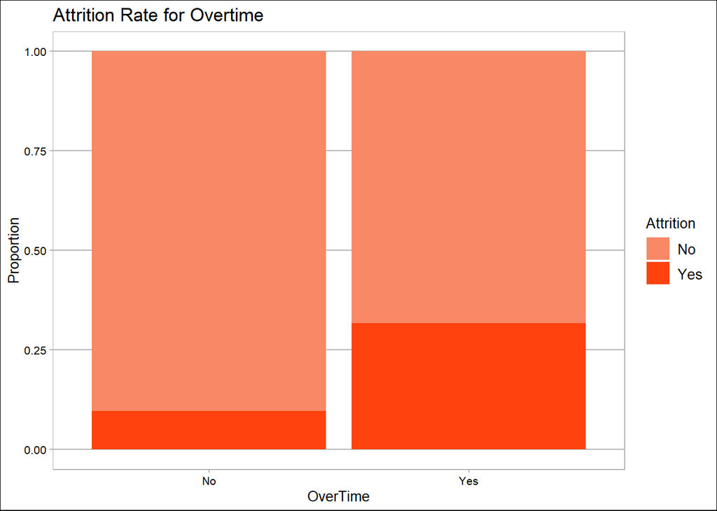

```r
csdata1 %>% ggplot(aes(x=OverTime, fill=Attrition))+geom_bar(position = "fill")+ggtitle("Attrition Rate for Overtime")+ylab("Proportion")+theme_calc()+theme_calc()+scale_fill_canva()
```

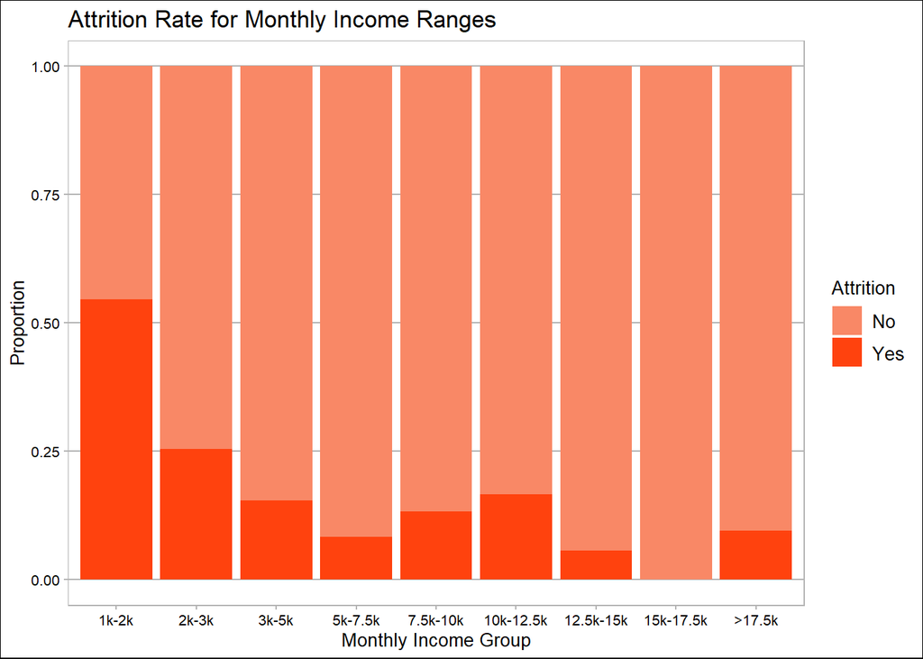

```r
csdata1 %>% ggplot(aes(x=fMonthlyIncome,fill=Attrition))+geom_bar(position = "fill")+ggtitle("Attrition Rate for Monthly Income Ranges")+ylab("Proportion")+theme_calc()+scale_fill_canva()+xlab("Monthly Income Group")
```

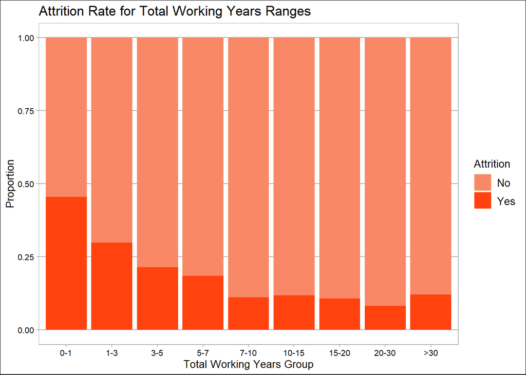

```r
csdata1 %>% ggplot(aes(x=fTotalWorkingYears,fill=Attrition))+geom_bar(position = "fill")+ggtitle("Attrition Rate for Total Working Years Ranges")+ylab("Proportion")+theme_calc()+scale_fill_canva()+xlab("Total Working Years Group")
```

Employees with overtime are about 3 times more likely to leave. THere is a downward trend in attrition for employees with higher salaries, with a small reversal for employees making over 7500 a month.

Fit a NaiveBayes model, tuning for the laplace transform to see if we can achieve a minimum .60 in both specificity and sensitivity.

```r
#naivebayes
set.seed(441)
loop_seq <- seq(0,5,.1)
df3 <- data.frame()
for (i in 1:51) {
  df_nb <- data.frame()
  for (j in 1:5) {
  csdata2 <- csdata1 %>% select(Attrition,OverTime,MonthlyIncome,TotalWorkingYears,YearsAtCompany,StockOptionLevel,MaritalStatus,JobLevel,YearsInCurrentRole,YearsWithCurrManager,Age,JobInvolvement,JobRole,JobSatisfaction,Department,DistanceFromHome,EnvironmentSatisfaction,WorkLifeBalance,TrainingTimesLastYear,Education,MonthlyRate,NumCompaniesWorked,DailyRate,RelationshipSatisfaction,HourlyRate,YearsSinceLastPromotion,BusinessTravel,EducationField,PercentSalaryHike)
  train_indx <- sample(1:nrow(csdata2), round(.7*nrow(csdata2)))
  train_nb <- csdata2[train_indx,]
  test_nb <- csdata2[-train_indx,]

  model <- naiveBayes(Attrition~.,train_nb,laplace = loop_seq[i])
  predictions <- predict(model,test_nb)
  cm <- confusionMatrix(predictions,test_nb$Attrition)
  df_cm <- data.frame("Accuracy"=cm$overall[1],"Sensitivity"=cm$byClass[1],"Specificity"=cm$byClass[2])
  df_nb <- rbind(df_nb,df_cm)
  }
  df3 <- rbind(df3,data.frame("mean acc"=mean(df_nb$Accuracy),"mean sens"=mean(df_nb$Sensitivity),"mean spec"=mean(df_nb$Specificity),"laplace"=i))
}
```

Curve showing the resulting mean accuracy, sensitivity and specificity for each value of the laplace transform. We can see the models were not able to reach the threshold consistently due to the unbalance in the category being studied (Attrition is 16%, which is significantly smaller than 50%)

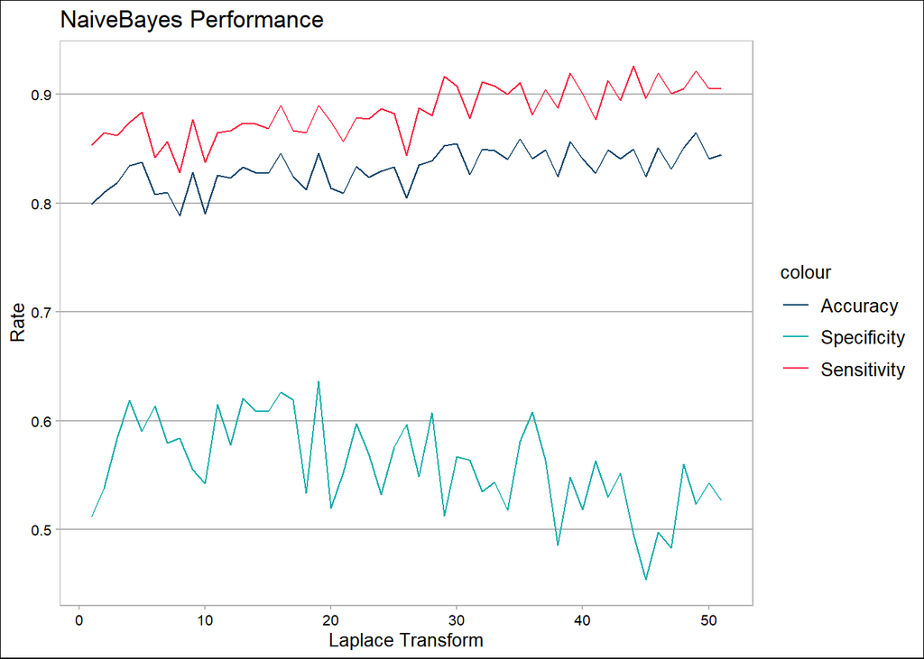

```r
df3 %>% ggplot(aes(x=laplace))+
  geom_line(aes(y=mean.acc,color="Accuracy"))+
  geom_line(aes(y=mean.spec, color="Specificity"))+
  geom_line(aes(y=mean.sens,color="Sensitivity"))+
  theme_calc()+scale_color_manual(
    values = c("Accuracy"="#074269", "Specificity"="#0EADAB","Sensitivity"="#FA2341"))+
      ggtitle("NaiveBayes Performance")+
      ylab("Rate")+
      xlab("Laplace Transform")
```

We will use a Random Forest model which has better performance with unbalanced data. We will find a starting value for the mtry parameter using the train function.

```r
#randomforest
set.seed(461)
df_data <- csdata1

train_indx <- sample(1:nrow(df_data), round(.7*nrow(df_data)))
train_exp <- df_data[train_indx,1:41]
train_resp <- df_data[train_indx,42]
test_nb <- df_data[-train_indx,]
rf_train <- train(train_exp,train_resp,method = "rf")
varImp(rf_train,scale = FALSE)
```

```
## rf variable importance
##
##   only 20 most important variables shown (out of 41)
##
##                         Overall
## OverTime                 13.310
## MonthlyIncome            11.058
## YearsSinceLastPromotion   9.608
## StockOptionLevel          8.411
## JobRole                   8.257
## NumCompaniesWorked        7.712
## fTotalWorkingYears        5.234
## DailyRate                 5.018
## fMonthlyIncome            4.817
## Age                       4.808
## HourlyRate                4.663
## MonthlyRate               4.373
## fYearsAtCompany           4.338
## EducationField            4.164
## EnvironmentSatisfaction   4.141
## fMonthlyRate              4.089
## fDailyRate                4.027
## DistanceFromHome          3.911
## JobInvolvement            3.831
## fDistanceFromHome         3.673
```

Fit the model using mtry=16, and adjusting the cutoff values to .68 for no attrition, and .15 for attrition. Create 10 random 70-30 splits to assess model performance.

```r
set.seed(1821)
df_data <- csdata1
df_rf <- data.frame()
for (i in 1:10) {
  train_indx <- sample(1:nrow(df_data), round(.7*nrow(df_data)))
  train_rf <- df_data[train_indx,]
  test_nb <- df_data[-train_indx,]

  rf <- randomForest(Attrition~.,data = train_rf, mtry=16,ntree=300, cutoff = c(.68,.15))
  rf_predict <- predict(rf,test_nb)
  rf_cm <- confusionMatrix(rf_predict,test_nb$Attrition)
  rf_specs <- data.frame("Accuracy"=rf_cm$overall[1],"Sensitivity"=rf_cm$byClass[1],"Specificity"=rf_cm$byClass[2])
  df_rf <- rbind(df_rf,rf_specs)
}

summary(df_rf)
```

```
##     Accuracy       Sensitivity      Specificity
##  Min.   :0.6322   Min.   :0.6063   Min.   :0.6500
##  1st Qu.:0.6609   1st Qu.:0.6377   1st Qu.:0.7027
##  Median :0.6858   Median :0.6712   Median :0.7615
##  Mean   :0.6843   Mean   :0.6711   Mean   :0.7600
##  3rd Qu.:0.7002   3rd Qu.:0.7006   3rd Qu.:0.8054
##  Max.   :0.7510   Max.   :0.7626   Max.   :0.9000
```

```r
df_rf <- df_rf %>% mutate("Iteration"=1:nrow(df_rf))
```

Plot the model accuracy, specificity and sensitivity over the 10 iterations.

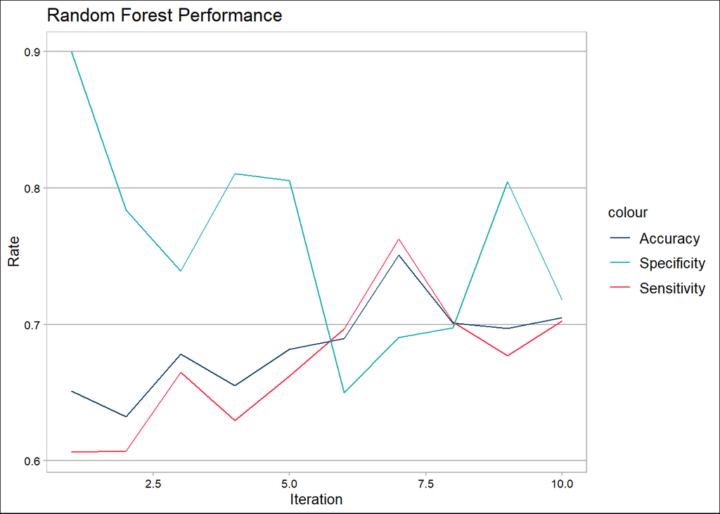

```r
df_rf %>% ggplot(aes(x=Iteration))+
  geom_line(aes(y=Accuracy,color="Accuracy"))+
  geom_line(aes(y=Sensitivity,color="Sensitivity"))+
  geom_line(aes(y=Specificity,color="Specificity"))+
  theme_calc()+scale_color_manual(
    values = c("Accuracy"="#074269", "Specificity"="#0EADAB","Sensitivity"="#FA2341"))+
      ggtitle("Random Forest Performance")+
      ylab("Rate")+
      xlab("Iteration")
```

Use the forward selection automatic method to find ideal variables to include in the model

```r
#regression for salary
lm_data <- csdata1 %>% select(-fMonthlyIncome)
lm_all <- lm(MonthlyIncome~.,lm_data)
stepAIC(lm_all,direction = "forward")#find a model
```

```
## Start:  AIC=12157.08
## MonthlyIncome ~ Age + BusinessTravel + DailyRate + Department +
##     DistanceFromHome + Education + EducationField + EnvironmentSatisfaction +
##     Gender + HourlyRate + JobInvolvement + JobLevel + JobRole +
##     JobSatisfaction + MaritalStatus + MonthlyRate + NumCompaniesWorked +
##     OverTime + PercentSalaryHike + PerformanceRating + RelationshipSatisfaction +
##     StockOptionLevel + TotalWorkingYears + TrainingTimesLastYear +
##     WorkLifeBalance + YearsAtCompany + YearsInCurrentRole + YearsSinceLastPromotion +
##     YearsWithCurrManager + fAge + fDailyRate + fDistanceFromHome +
##     fHourlyRate + fMonthlyRate + fPercentSalaryHike + fTotalWorkingYears +
##     fYearsAtCompany + fYearsInCurrentRole + fYearsWithCurrManager +
##     Attrition
```

```
##
## Call:
## lm(formula = MonthlyIncome ~ Age + BusinessTravel + DailyRate +
##     Department + DistanceFromHome + Education + EducationField +
##     EnvironmentSatisfaction + Gender + HourlyRate + JobInvolvement +
##     JobLevel + JobRole + JobSatisfaction + MaritalStatus + MonthlyRate +
##     NumCompaniesWorked + OverTime + PercentSalaryHike + PerformanceRating +
##     RelationshipSatisfaction + StockOptionLevel + TotalWorkingYears +
##     TrainingTimesLastYear + WorkLifeBalance + YearsAtCompany +
##     YearsInCurrentRole + YearsSinceLastPromotion + YearsWithCurrManager +
##     fAge + fDailyRate + fDistanceFromHome + fHourlyRate + fMonthlyRate +
##     fPercentSalaryHike + fTotalWorkingYears + fYearsAtCompany +
##     fYearsInCurrentRole + fYearsWithCurrManager + Attrition,
##     data = lm_data)
##
## Coefficients:
##                      (Intercept)                               Age
##                        4.431e+03                        -2.699e+01
##  BusinessTravelTravel_Frequently       BusinessTravelTravel_Rarely
##                        1.995e+02                         3.151e+02
##                        DailyRate  DepartmentResearch & Development
##                        2.891e-01                        -4.117e+02
##                  DepartmentSales                  DistanceFromHome
##                       -8.662e+02                         1.093e+01
##                       Education2                        Education3
##                        4.791e+01                        -7.478e+01
##                       Education4                        Education5
##                        4.591e+01                        -5.157e+02
##      EducationFieldLife Sciences           EducationFieldMarketing
##                        9.202e+01                         1.041e+02
##            EducationFieldMedical               EducationFieldOther
##                        7.697e+01                         7.938e+01
##   EducationFieldTechnical Degree          EnvironmentSatisfaction2
##                        1.917e+01                        -6.289e+01
##         EnvironmentSatisfaction3          EnvironmentSatisfaction4
##                       -1.511e+01                        -5.309e+01
##                       GenderMale                        HourlyRate
##                        3.555e+01                         7.204e+00
##                  JobInvolvement2                   JobInvolvement3
##                       -3.822e+01                        -5.393e+01
```

[output cut: 115 more lines]

```
##                        3.394e+02                         5.539e+02
##           fYearsInCurrentRole3-5            fYearsInCurrentRole5-7
##                        6.777e+02                         1.051e+03
##          fYearsInCurrentRole7-10          fYearsInCurrentRole10-15
##                        1.568e+03                         2.435e+03
##           fYearsInCurrentRole>15          fYearsWithCurrManager1-2
##                        3.044e+03                         2.961e+02
##         fYearsWithCurrManager2-3          fYearsWithCurrManager3-5
##                        3.330e+02                         5.085e+02
##         fYearsWithCurrManager5-7         fYearsWithCurrManager7-10
##                        6.583e+02                         8.938e+02
##       fYearsWithCurrManager10-14          fYearsWithCurrManager>14
##                        1.417e+03                         2.495e+03
##                     AttritionYes
##                        7.437e+01
```

Adjust the model from the selection process, adding interactions and creating 10 random 70-30 splits to assess the model’s performance.

```r
set.seed(766)
lm_df <- data.frame()
for (i in 1:10) {
  #create a 70-30 train-test split each iteration
  lm_indx <- sample(1:nrow(lm_data), round(nrow(lm_data)*.7))
  lm_train <- lm_data[lm_indx,]
  lm_test <- lm_data[-lm_indx,]

  lm_modl <- lm(formula = MonthlyIncome ~BusinessTravel + DailyRate +
                  Department + Education + EducationField +
                  EnvironmentSatisfaction + Gender + JobInvolvement +
                  JobLevel + JobRole + JobSatisfaction + MaritalStatus + MonthlyRate +
                  NumCompaniesWorked + OverTime + PercentSalaryHike + PerformanceRating +
                  RelationshipSatisfaction + StockOptionLevel +
                  TrainingTimesLastYear + WorkLifeBalance + YearsAtCompany +
                  YearsInCurrentRole + YearsSinceLastPromotion + YearsWithCurrManager +
                  fAge + DailyRate*MaritalStatus + fDistanceFromHome + fHourlyRate + MonthlyRate*Education +
                  PercentSalaryHike*DailyRate + fTotalWorkingYears +
                  YearsInCurrentRole*JobInvolvement + YearsWithCurrManager*Education + Attrition,
                data = lm_data)
  lm_predic <- predict(lm_modl,lm_test)
  lm_rmse <- RMSE(lm_predic,lm_test$MonthlyIncome)
  lm_df <- rbind(lm_df,lm_rmse)
}
colnames(lm_df) <- c("RMSE")
lm_df <- lm_df %>% mutate("Iteration"=1:nrow(lm_df))
lm_df %>% kable(col.names=c("RMSE","Iteration")) %>% kable_styling(latex_options = c("striped","scale_down")) %>% row_spec(row=0,italic=T,background = "#9d0916",color="white") %>% column_spec(2,width = "4.3in")
```

| RMSE | Iteration |
| --- | --- |
| 925.2554 | 1 |
| 897.7730 | 2 |
| 896.9328 | 3 |
| 988.1178 | 4 |
| 870.6661 | 5 |
| 869.0759 | 6 |
| 953.9668 | 7 |
| 906.2357 | 8 |
| 934.9460 | 9 |
| 933.4506 | 10 |

```r
mean(lm_df$RMSE) %>% kable(col.names = "Mean RMSE") %>% kable_styling(latex_options = c("striped","scale_down")) %>% row_spec(row=0,italic = T,background = "#9d0916",color = 'White')
```

| Mean RMSE |
| --- |
| 917.642 |

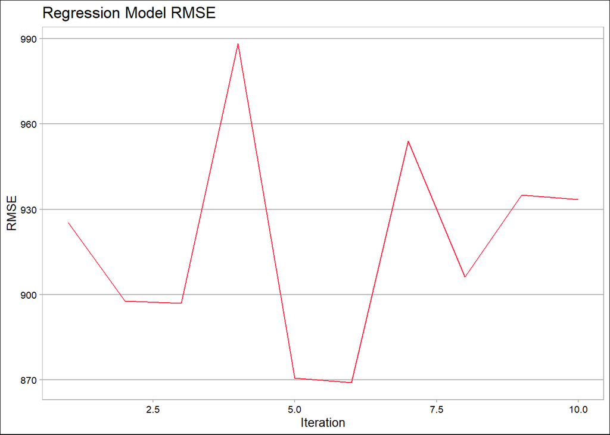

```r
lm_df %>% ggplot(aes(x=Iteration))+
  geom_line(aes(y=RMSE),color="#FA2341")+
  theme_calc()+
  ggtitle("Regression Model RMSE")
```

Both models are performing up to desired expectations. Finally, we will use the fitted models to predict the given test sets.

```r
#read table with no attrition
no_attr <- read.csv("CaseStudy2CompSet No Attrition.csv")
#apply same transformations as original data
no_attr <- no_attr %>% mutate(fAge=cut(Age,
                                     breaks=c(10,20,25,30,40,50,80),
                                     labels=c("18-20", "21-25", "26-30", "31-40","40-50", "50+")),
                             BusinessTravel=as.factor(BusinessTravel),
                             fDailyRate=cut(DailyRate,
                                           DailyRate,
                                           breaks=c(100,200,300,500,750,1000,1250,1500),
                                           labels=c("100-200", "201-300", "301-500", "501-750", "751-1000", "1001-1250", "1251+")),
                             Department=as.factor(Department),
                             fDistanceFromHome=cut(DistanceFromHome,
                                                 breaks=c(0,5,10,15,20,25,30),
                                                 labels=c("<5","6-10","11-15","16-20","21-25","26-30")),
                             Education=as.factor(Education),
                             EducationField=as.factor(EducationField),
                             EnvironmentSatisfaction=as.factor(EnvironmentSatisfaction),
                             Gender=as.factor(Gender),
                             fHourlyRate=cut(HourlyRate,
                                            breaks=c(0,40,50,60,75,90,200),
                                            labels=c("<40","41-50","51-60","61-75","76-90","90+")),
                             JobInvolvement=as.factor(JobInvolvement),
                             JobLevel=as_factor(JobLevel),
                             JobRole=as.factor(JobRole),
                             JobSatisfaction=as.factor(JobSatisfaction),
                             MaritalStatus=as.factor(MaritalStatus),
                             fMonthlyIncome=cut(MonthlyIncome,
                                               breaks=c(0,1000,2000,3000,5000,7500,10000,12500,15000,17500,50000),
                                               labels=c("<1k","1k-2k","2k-3k","3k-5k","5k-7.5k","7.5k-10k","10k-12.5k","12.5k-15k","15k-17.5k",">17.5k")),
                             fMonthlyRate=cut(MonthlyRate,
                                             breaks=c(0,3000,5000,7500,10000,15000,20000,400000),
                                             labels=c("<3k","3k-5k","5k-7.5k","7.5k-10k","10k-15k","15k-20k",">20k")),
                             NumCompaniesWorked=as.factor(NumCompaniesWorked),
                             OverTime=as.factor(OverTime),
                             fPercentSalaryHike=cut(PercentSalaryHike,
                                                   breaks=c(0,10,12,14,16,18,20,22,100),
                                                   labels=c("<10%","10-12%","12-14%","14-16%","16-18%","18-20%","20-22%","<22%")),
                             PerformanceRating=as.factor(PerformanceRating),
                             RelationshipSatisfaction=as.factor(RelationshipSatisfaction),
                             StockOptionLevel=as.factor(StockOptionLevel),
                             fTotalWorkingYears=cut(TotalWorkingYears,
                                                   breaks=c(-1,1,3,5,7,10,15,20,30,60),
                                                   labels=c("0-1","1-3","3-5","5-7","7-10","10-15","15-20","20-30",">30")),
                             TrainingTimesLastYear=as.factor(TrainingTimesLastYear),
                             WorkLifeBalance=as.factor(WorkLifeBalance),
                             fYearsAtCompany=cut(YearsAtCompany,
                                                breaks=c(-1,1,2,3,5,7,10,15,20,60),
                                                labels=c("0-1","1-2","2-3","3-5","5-7","7-10","10-15","15-20",">20")),
                             fYearsInCurrentRole=cut(YearsInCurrentRole,
                                                    breaks=c(-1,1,2,3,5,7,10,15,60),
                                                    labels=c("0-1","1-2","2-3","3-5","5-7","7-10","10-15",">15")),
                             YearsSinceLastPromotion=as.factor(YearsSinceLastPromotion),
                             fYearsWithCurrManager=cut(YearsWithCurrManager,
                                                      breaks=c(-1,1,2,3,5,7,10,14,60),
                                                      labels=c("0-1","1-2","2-3","3-5","5-7","7-10","10-14",">14")))
no_attr <- no_attr %>% select(-c(9,10,22,27))#drop unusable columns

#predict Attrition and save file
attr_pred <- predict(rf,no_attr)
attr_pred <- data.frame("ID"=no_attr$ID,"Attrition"=attr_pred)

write.csv(attr_pred,"Classify_NoAttrition.csv",row.names = FALSE)
```

```r
no_salary <- read_xlsx("CaseStudy2CompSet No Salary.xlsx")

no_salary <- no_salary %>% mutate(fAge=cut(Age,
                                     breaks=c(10,20,25,30,40,50,80),
                                     labels=c("18-20", "21-25", "26-30", "31-40","40-50", "50+")),
                             Attrition=as.factor(Attrition),
                             BusinessTravel=as.factor(BusinessTravel),
                             fDailyRate=cut(DailyRate,
                                           DailyRate,
                                           breaks=c(100,200,300,500,750,1000,1250,1500),
                                           labels=c("100-200", "201-300", "301-500", "501-750", "751-1000", "1001-1250", "1251+")),
                             Department=as.factor(Department),
                             fDistanceFromHome=cut(DistanceFromHome,
                                                 breaks=c(0,5,10,15,20,25,30),
                                                 labels=c("<5","6-10","11-15","16-20","21-25","26-30")),
                             Education=as.factor(Education),
                             EducationField=as.factor(EducationField),
                             EnvironmentSatisfaction=as.factor(EnvironmentSatisfaction),
                             Gender=as.factor(Gender),
                             fHourlyRate=cut(HourlyRate,
                                            breaks=c(0,40,50,60,75,90,200),
                                            labels=c("<40","41-50","51-60","61-75","76-90","90+")),
                             JobInvolvement=as.factor(JobInvolvement),
                             JobLevel=as_factor(JobLevel),
                             JobRole=as.factor(JobRole),
                             JobSatisfaction=as.factor(JobSatisfaction),
                             MaritalStatus=as.factor(MaritalStatus),
                             fMonthlyRate=cut(MonthlyRate,
                                             breaks=c(0,3000,5000,7500,10000,15000,20000,400000),
                                             labels=c("<3k","3k-5k","5k-7.5k","7.5k-10k","10k-15k","15k-20k",">20k")),
                             NumCompaniesWorked=as.factor(NumCompaniesWorked),
                             OverTime=as.factor(OverTime),
                             fPercentSalaryHike=cut(PercentSalaryHike,
                                                   breaks=c(0,10,12,14,16,18,20,22,100),
                                                   labels=c("<10%","10-12%","12-14%","14-16%","16-18%","18-20%","20-22%","<22%")),
                             PerformanceRating=as.factor(PerformanceRating),
                             RelationshipSatisfaction=as.factor(RelationshipSatisfaction),
                             StockOptionLevel=as.factor(StockOptionLevel),
                             fTotalWorkingYears=cut(TotalWorkingYears,
                                                   breaks=c(-1,1,3,5,7,10,15,20,30,60),
                                                   labels=c("0-1","1-3","3-5","5-7","7-10","10-15","15-20","20-30",">30")),
                             TrainingTimesLastYear=as.factor(TrainingTimesLastYear),
                             WorkLifeBalance=as.factor(WorkLifeBalance),
                             fYearsAtCompany=cut(YearsAtCompany,
                                                breaks=c(-1,1,2,3,5,7,10,15,20,60),
                                                labels=c("0-1","1-2","2-3","3-5","5-7","7-10","10-15","15-20",">20")),
                             fYearsInCurrentRole=cut(YearsInCurrentRole,
                                                    breaks=c(-1,1,2,3,5,7,10,15,60),
                                                    labels=c("0-1","1-2","2-3","3-5","5-7","7-10","10-15",">15")),
                             YearsSinceLastPromotion=as.factor(YearsSinceLastPromotion),
                             fYearsWithCurrManager=cut(YearsWithCurrManager,
                                                      breaks=c(-1,1,2,3,5,7,10,14,60),
                                                      labels=c("0-1","1-2","2-3","3-5","5-7","7-10","10-14",">14")))

salary_pred <- predict(lm_modl,no_salary)
salary_pred <- data.frame("ID"=no_salary$ID, "MonthlyIncome"=salary_pred)

write.csv(salary_pred,"Regress_NoSalary.csv",row.names = FALSE)
```